# Explore covariates for modeling

## 5.3. Histograms at 5000 m

Let’s repeat the exercise at 5000 m to give us a sense of how this might change with increasing scale:

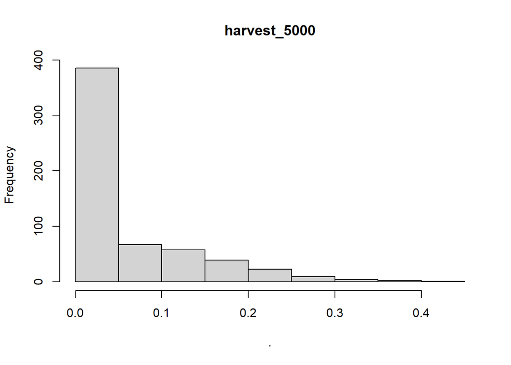

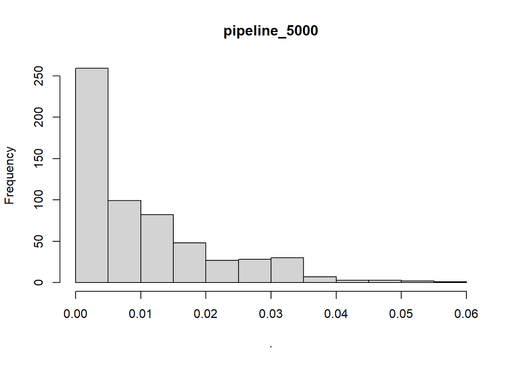

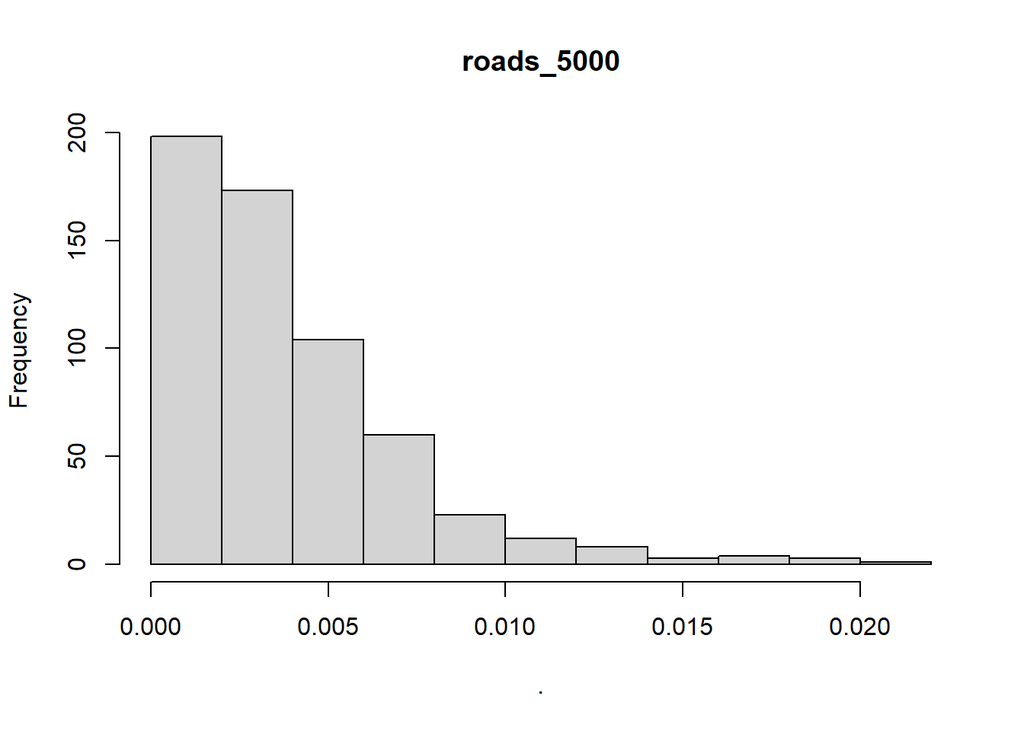

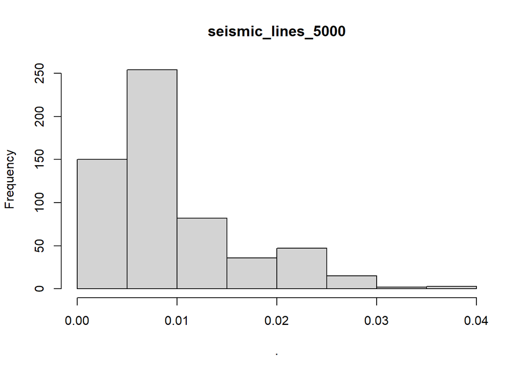

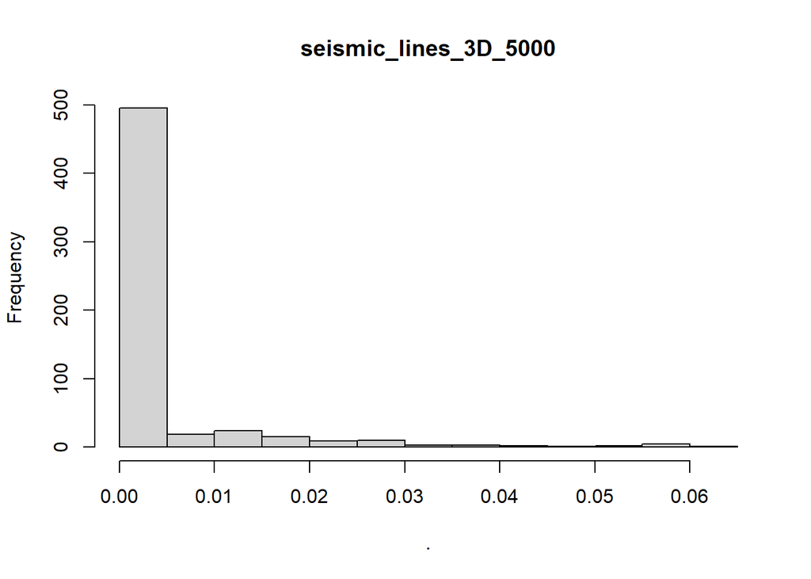

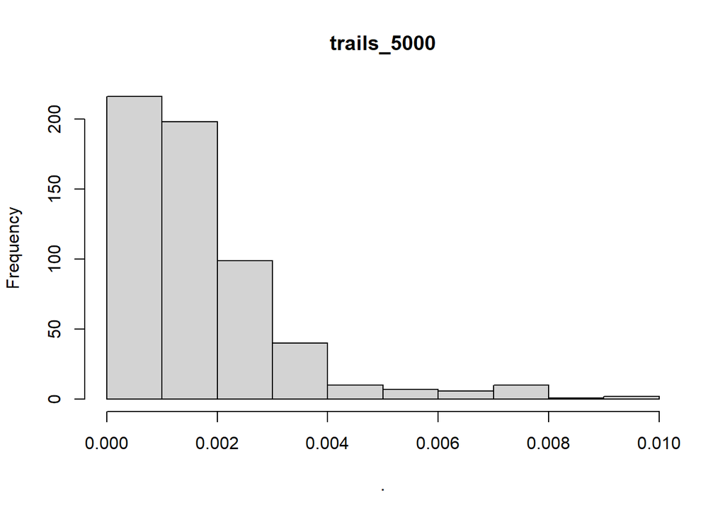

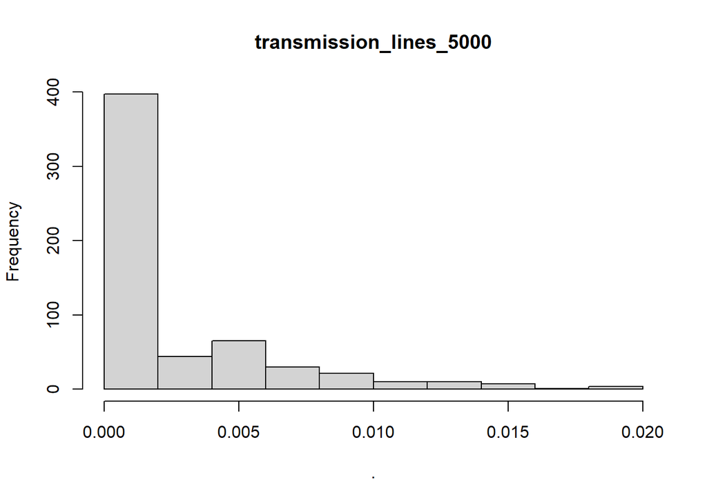

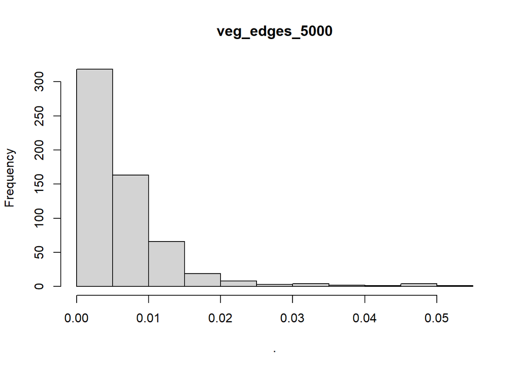

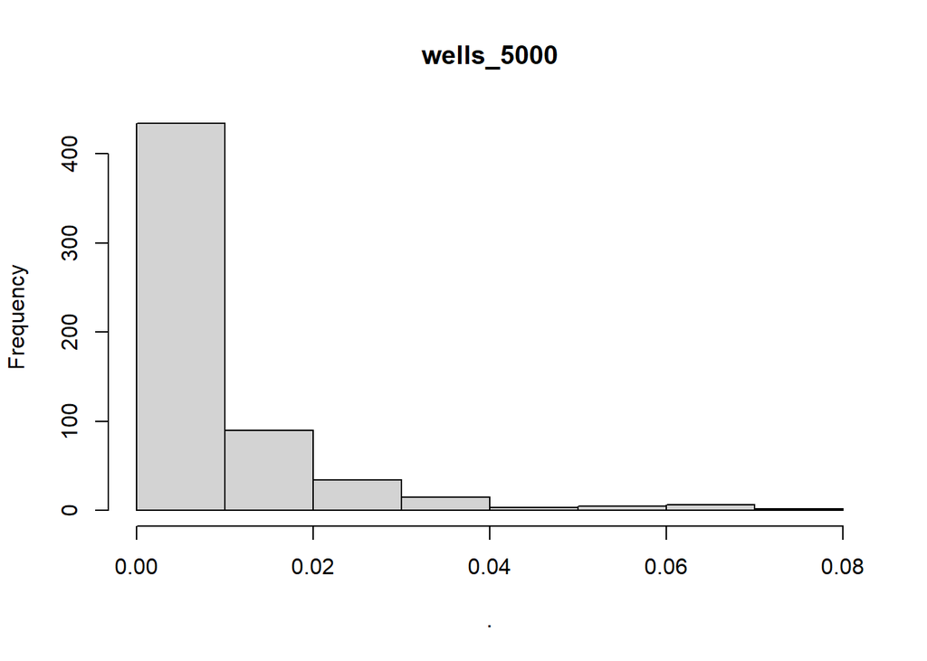

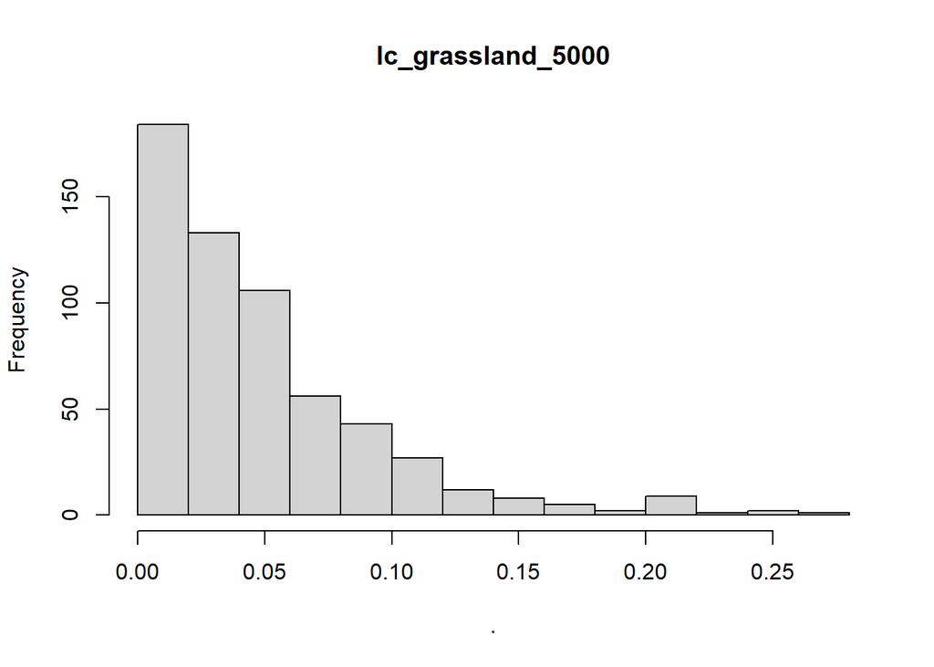

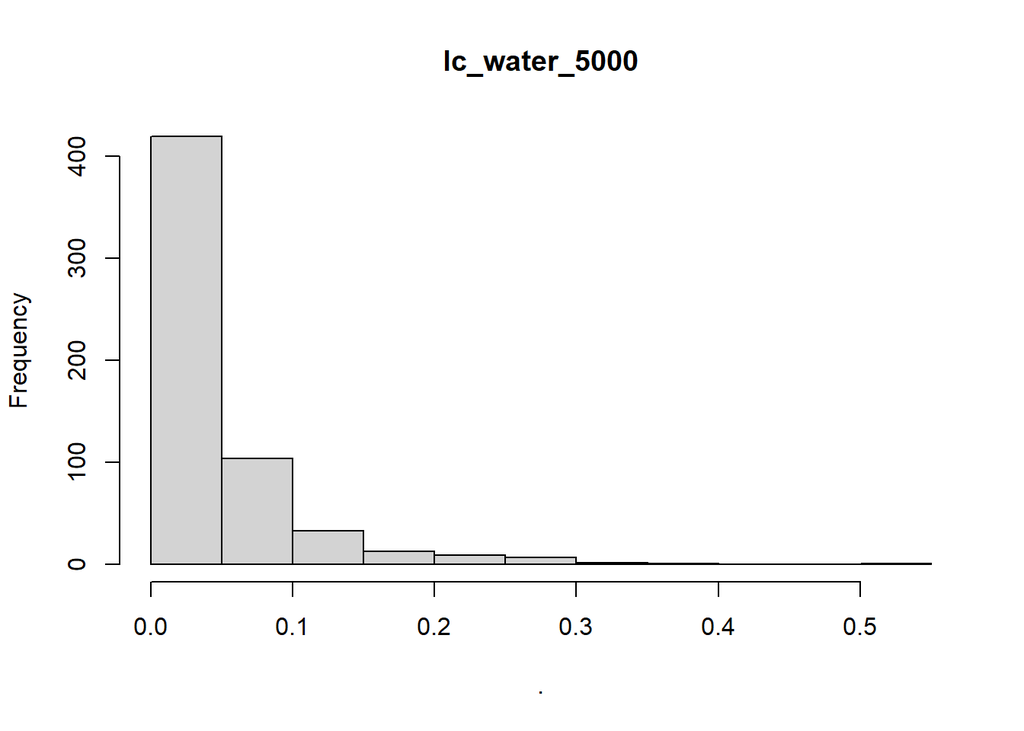

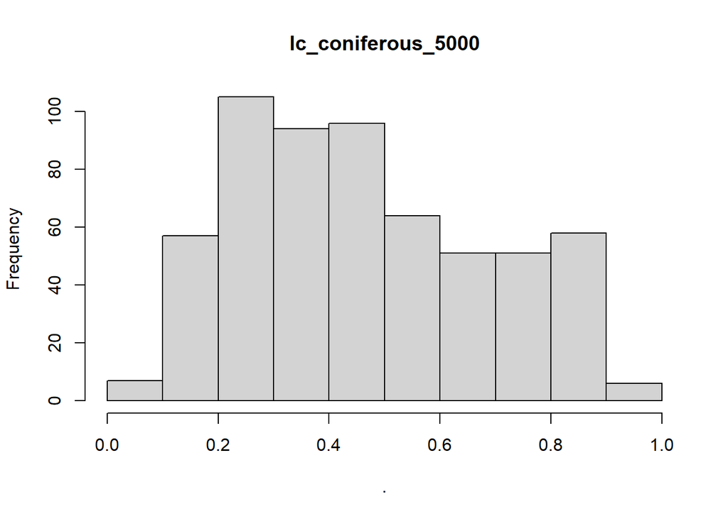

[7 more figures not shown]

[output not shown]

[output cut: 393 more lines]

```
## $density
## [1]  7.215620  3.310696  4.244482  0.000000  5.178268 22.410866  0.000000
## [8]  0.000000  7.640068
##
## $mids
## [1] 0.03 0.05 0.07 0.09 0.11 0.13 0.15 0.17 0.19
##
## $xname
## [1] "."
##
## $equidist
## [1] TRUE
##
## attr(,"class")
## [1] "histogram"
```

```r
# using purr solution
data %>%

  select(contains('_5000')) %>%

  # use imap which will retain both the data (x) and the variable names (y)
  imap(~.x %>%

         # use the hist function on the data from previous pipe
        hist(.,

             # set the main title to y (each variable)
             main = .y))
```

> At 5000 meters, we get some, but not a ton of, variation for:
> - 3D seismic lines (*seismic_lines_3D_5000*)
> - Industrial sites (*osm_industrial_5000*)

## 5.4. Histograms of predators

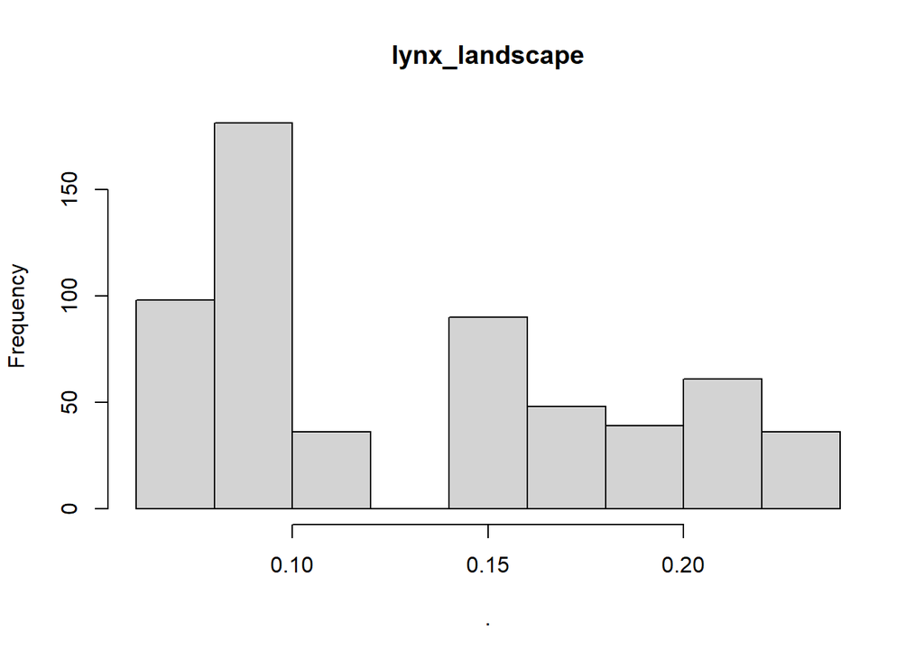

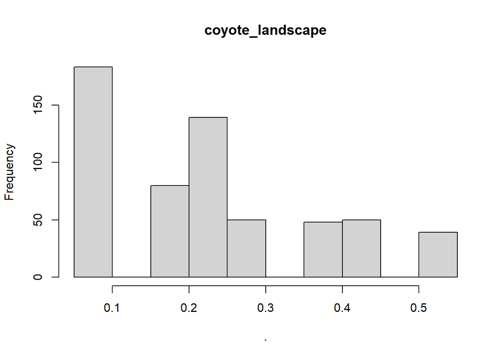

```
## $lynx_landscape
## $breaks
##  [1] 0.06 0.08 0.10 0.12 0.14 0.16 0.18 0.20 0.22 0.24
##
## $counts
## [1]  98 181  36   0  90  48  39  61  36
##
## $density
## [1]  8.319185 15.365025  3.056027  0.000000  7.640068  4.074703  3.310696
## [8]  5.178268  3.056027
##
## $mids
## [1] 0.07 0.09 0.11 0.13 0.15 0.17 0.19 0.21 0.23
##
## $xname
## [1] "."
##
## $equidist
## [1] TRUE
##
## attr(,"class")
## [1] "histogram"
##
## $coyote_landscape
## $breaks
##  [1] 0.05 0.10 0.15 0.20 0.25 0.30 0.35 0.40 0.45 0.50 0.55
##
## $counts
##  [1] 183   0  80 139  50   0  48  50   0  39
##
## $density
##  [1] 6.213922 0.000000 2.716469 4.719864 1.697793 0.000000 1.629881 1.697793
##  [9] 0.000000 1.324278
##
## $mids
##  [1] 0.075 0.125 0.175 0.225 0.275 0.325 0.375 0.425 0.475 0.525
##
## $xname
## [1] "."
##
## $equidist
## [1] TRUE
##
## attr(,"class")
## [1] "histogram"
```

```r
# using purr solution
data %>%

  select(lynx_landscape, coyote_landscape) %>%

  # use imap which will retain both the data (x) and the variable names (y)
  imap(~.x %>%

         # use the hist function on the data from previous pipe
        hist(.,

             # set the main title to y (each variable)
             main = .y))
```

So it looks like the main variables of interest that have low variation are industrial sites, 3D seismic lines, and water. Vegetated edges and transmission lines might be useful but given how specific they are they might be best off getting lumped into a single category of ‘cleared features’, if we even decide that we want to use them. Vegetated road edges obviously correspond with roads so we could consider pooling these into the road class if we deem this an appropriate representation of roads. Importantly, depending on how our modeling goes it could be worthwhile to pool low-impact (3D) and conventional seismic lines into a single ‘seismic line’ class across spatial scales.

## 5.5. Correlation at allspatial scales

Now let’s look at whether there is correlation among any of our explanatory variables. We’ll use the handy `chart.Correlation()` function from the `PerformanceAnalytics` package to do this.